# tidyverse_types of visualisation

Manojit Sarkar

20 July 2018

## Types of Visualisation

lets start with loading the required libraries

```r
library(tidyverse)
library(gapminder)
```

# 1. Line Plots (good for showing change over time)

lets dig in

```r
by_continent_year<-gapminder%>%
  group_by(continent,year)%>%
  summarize(meanLifeExp=mean(lifeExp))
```

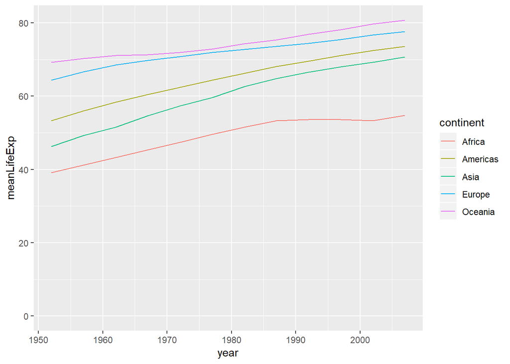

```r
ggplot(by_continent_year,aes(x=year,y=meanLifeExp,color=continent))+geom_line()+expand_limits(y=0)
```

one more examples:

Create a line plot showing the change in medianGdpPercap by continent over time

first we need to summarize the dataset for the meadian value

```r
by_year_continent<-gapminder%>%
                    group_by(year,continent)%>%
                    summarize(medianGdpPercap=median(gdpPercap))
```

then the plotting part

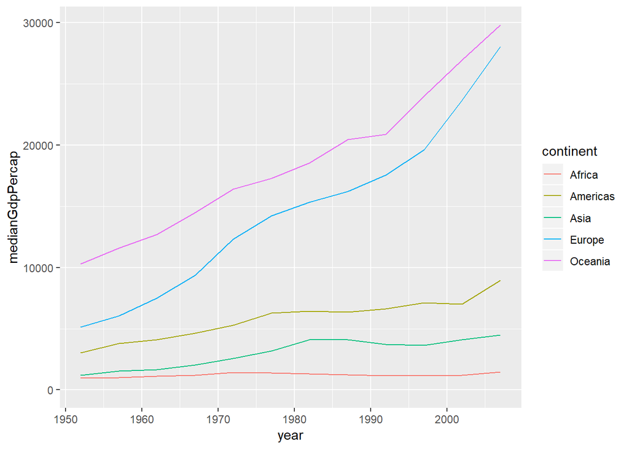

```r
ggplot(by_year_continent,aes(x=year,y=medianGdpPercap,color=continent))+geom_line()+expand_limits(y=0)
```

# 2.Bar Plots (good for showing statistics for each of several categories)

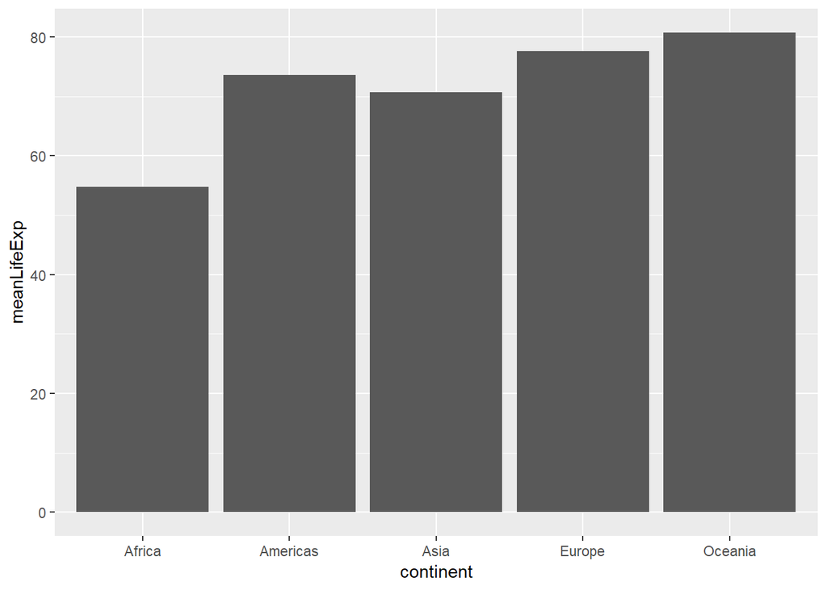

```r
by_continent_2007<-gapminder%>%
                    filter(year==2007)%>%
                    group_by(continent)%>%
                    summarize(meanLifeExp=mean(lifeExp))

## lets plot the bar plot

ggplot(by_continent_2007,aes(x=continent,y=meanLifeExp))+geom_col()
```

Cool !!

# 3.Histograms (describe the distribution of one-dimensional numeric variable)

With Histograms we investigate one dimension of the data at a time

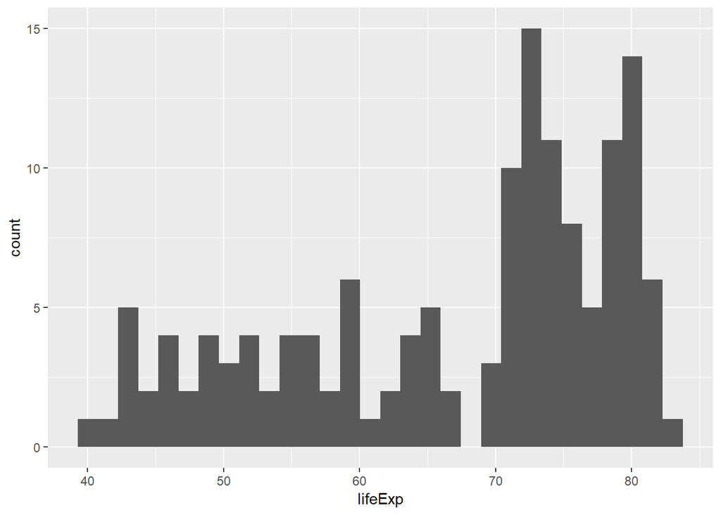

```r
by_year_2007<-gapminder%>%
                filter(year==2007)

ggplot(by_year_2007,aes(x=lifeExp))+geom_histogram(bins=30)
```

Its a distribution of life expectancy across countries in the year 2007. Where each bar represents a bucket/bin of life expactancy and the height represents how many countries fall into that bucket/bin.

most countries have a life expectancy of 70 -80 years also there is a set of countries whose life expectancy falls between 40 -65 years.

# 4.Boxplot (which compares the distribution of a numeric variable among several categories)

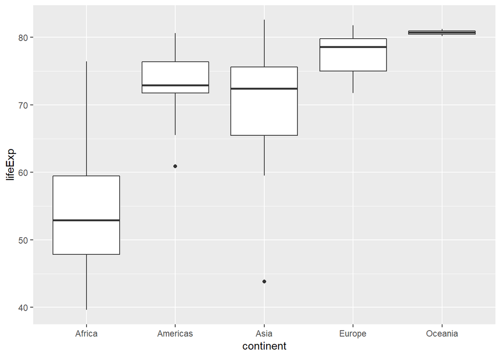

```r
year_2007<-gapminder%>%
            filter(year==2007)

ggplot(year_2007, aes(x = continent, y = lifeExp)) +
  geom_boxplot()
```

it shows the life expectancy of each continent in the year 2007, so that we can compare them.

the black line in the middle of each box is the median the top and the bottom part are the 75th and 25th percentile respectively, meaning half of the distribution lies within the box. the line going up and down the box are called whiskers , cover other half of the countries. the two dots otside the lines for asia and americas are the outliers (countries with low life expectancy than their respective distribution). We can also see that the median life expectancy of europe is one the highestand the two countries of Oceania Australia and NewZeland both have very high values. the life expectancy of africa is unusually low because half of the countries in africa have a life expectancy between 50 and 60.

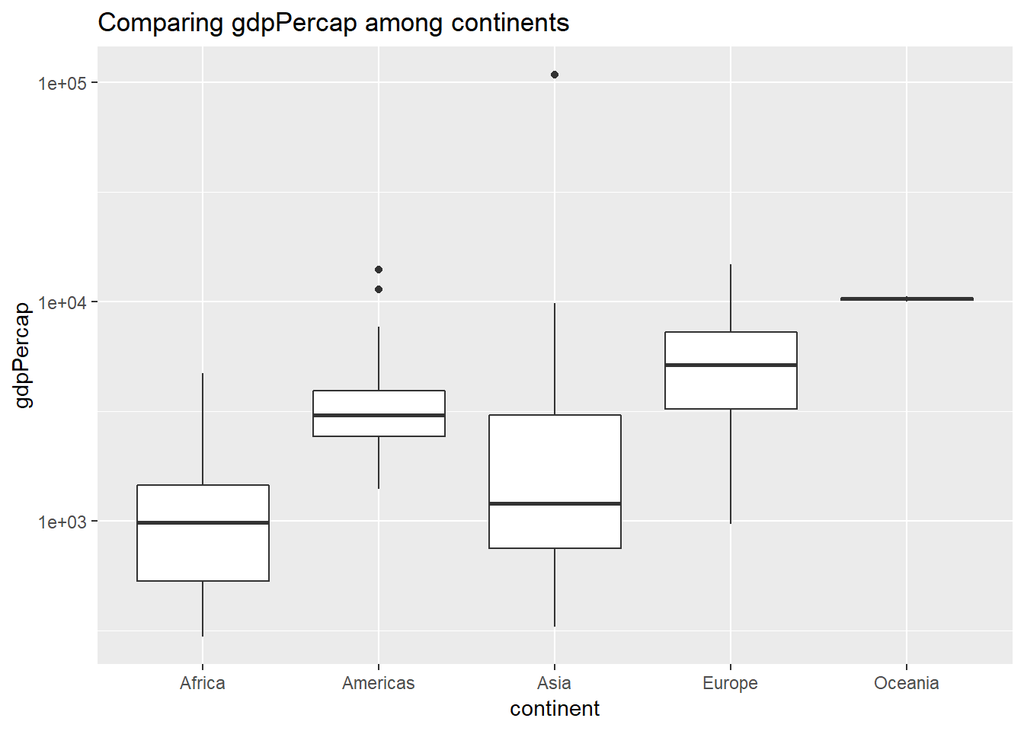

```r
gapminder_1952 <- gapminder %>%
  filter(year == 1952)

# Create a boxplot comparing gdpPercap among continents
 ggplot(gapminder_1952,aes(x=continent,y=gdpPercap))+geom_boxplot()+scale_y_log10()+ggtitle(("Comparing gdpPercap among continents"))
```

Again Africa has the lowest GDP per capita income.

Also we added a title to the plot :)

Thats all for now folks and May the force be with you!!!!